# Repair Cafe

Author

Jo Hardin

Published

April 7, 2026

```r
library(tidyverse) # ggplot, lubridate, dplyr, stringr, readr...
library(praise)
```

# Repair Cafes Worldwide

The dataset this week comes from the [Repair Monitor](https://dashboard.repairmonitor.org/?language=en), which has been compiling data from Repair Cafes worldwide since 2015. Repair Cafe branches bring together volunteer fixers to help people learn how to repair household items that are broken.

Note: There appears to be some uncertainty (by submitters to the source data) of what to put in `repair_info_source` and `repair_info_url`. We included the questions for these fields to aid in the interpretation of the data.

> As carbon-hungry consumer production and its subsequent waste surge to all-time highs, experts say that the concept can help curb pollution while promoting a more circular economy.
- What kinds of items are most easily repaired?
- What are the most common reasons that items can’t be repaired?
- Which countries have seen the most growth in Repair Cafe branches?
- Is GenAI becoming more popular than YouTube as a source of useful information for repairers?

Thank you to [Jen Richmond](https://github.com/jenrichmond) for curating this week’s dataset.

# The Data

```r
repairs <- readr::read_csv('https://raw.githubusercontent.com/rfordatascience/tidytuesday/main/data/2026/2026-04-07/repairs.csv')
repairs_text <- readr::read_csv('https://raw.githubusercontent.com/rfordatascience/tidytuesday/main/data/2026/2026-04-07/repairs_text.csv')
```

```r
repairs |>
  group_by(brand) |>
  summarize(count = n()) |>
  arrange(desc(count))
```

```
# A tibble: 8,601 × 2
   brand        count
   <chr>        <int>
 1 Unknown/n.a. 78902
 2 Philips      10649
 3 Bosch         3005
 4 Sony          2576
 5 Miele         2055
 6 Tefal         1692
 7 Samsung       1599
 8 Dyson         1562
 9 HP            1411
10 Black+Decker  1240
# ℹ 8,591 more rows
```

```r
repairs |>
  filter(brand %in% c("Philips", "Bosch", "Sony", "Miele", "Tefal")) |>
  group_by(brand) |>
  summarize(mean_repair = mean(repairability, na.rm = TRUE))
```

```
# A tibble: 5 × 2
  brand   mean_repair
  <chr>         <dbl>
1 Bosch          6.51
2 Miele          6.38
3 Philips        6.35
4 Sony           5.88
5 Tefal          6.32
```

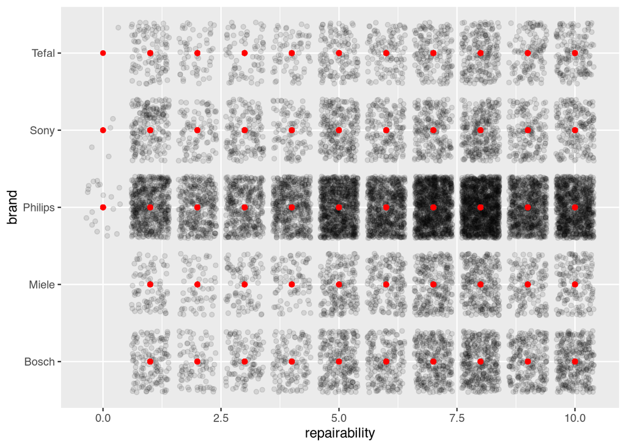

```r
repairs |>
  filter(brand %in% c("Philips", "Bosch", "Sony", "Miele", "Tefal")) |>
  ggplot() +
  geom_jitter(aes(x = repairability, y = brand), alpha = .1)+
  geom_point(aes(x = repairability, y = brand), color = "red")
```

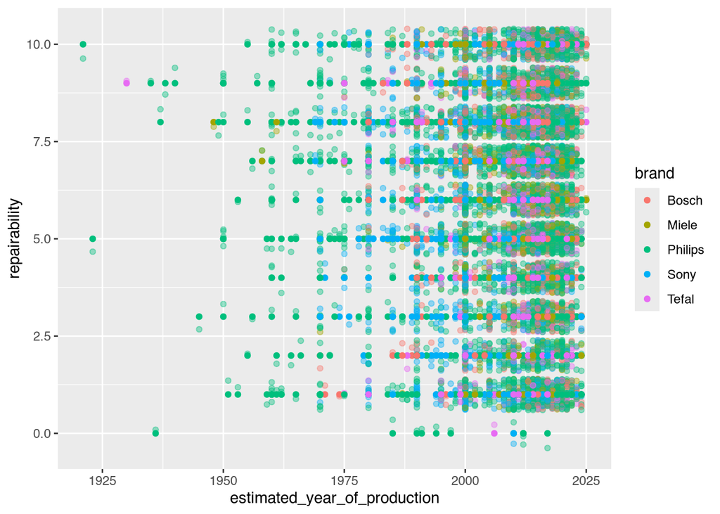

```r
repairs |>
  filter(brand %in% c("Philips", "Bosch", "Sony", "Miele", "Tefal")) |>
  filter(estimated_year_of_production > 1910, estimated_year_of_production < 2026) |>
  ggplot() +
  geom_jitter(aes(x = estimated_year_of_production, y = repairability,
                 color = brand), width = 0, alpha = 0.4) +
  geom_point(aes(x = estimated_year_of_production, y = repairability, color = brand))
```

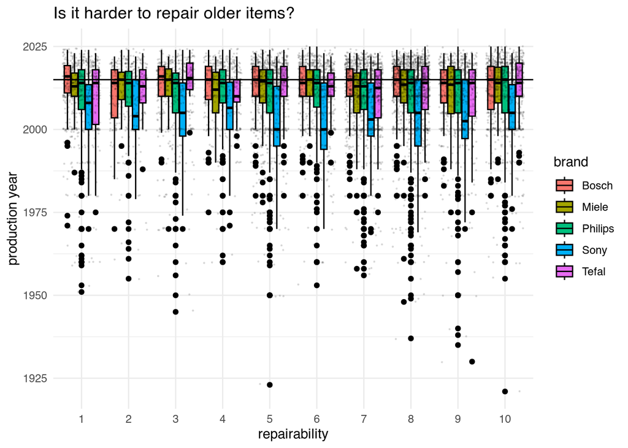

For the 5 most frequent brands in the Repair Cafe dataset, how do the production year and the repairability compare? (Repairability is on a scale of 1 (difficult) to 10 (easy).) There do not seem to be any strong trends across time or brand.

```r
repairs |>
  filter(brand %in% c("Philips", "Bosch", "Sony", "Miele", "Tefal")) |>
  filter(estimated_year_of_production > 1910, estimated_year_of_production < 2026) |>
  filter(!is.na(repairability)) |>
  filter(repairability > 0) |>
  ggplot() +
  geom_boxplot(aes(y = estimated_year_of_production, x = as.factor(repairability),
                 fill = brand), color = "black") +
  geom_jitter(aes(y = estimated_year_of_production, x = as.factor(repairability)),
              alpha = 0.1, size = 0.2) +
  geom_hline(yintercept = 2015) +
  theme_minimal() +
  labs(x = "repairability", y = "production year",
       title = "Is it harder to repair older items?")
```

```r
praise()
```

```
[1] "You are sublime!"
```